# hw3

Alicia Hauglie

2/15/2019

```r
data(tips, package="reshape2")
library(ggplot2)
```

1. How many parties did the waiter serve? Store the number in numParty and print.

```r
numParty<- nrow(tips)
numParty
```

```
## [1] 244
```

2. What are the types of variables in the data frame tips?

```r
str(tips$total_bill)
```

```
##  num [1:244] 17 10.3 21 23.7 24.6 ...
```

```r
str(tips$tip)
```

```
##  num [1:244] 1.01 1.66 3.5 3.31 3.61 4.71 2 3.12 1.96 3.23 ...
```

```r
str(tips$sex)
```

```
##  Factor w/ 2 levels "Female","Male": 1 2 2 2 1 2 2 2 2 2 ...
```

```r
str(tips$smoker)
```

```
##  Factor w/ 2 levels "No","Yes": 1 1 1 1 1 1 1 1 1 1 ...
```

```r
str(tips$day)
```

```
##  Factor w/ 4 levels "Fri","Sat","Sun",..: 3 3 3 3 3 3 3 3 3 3 ...
```

```r
str(tips$time)
```

```
##  Factor w/ 2 levels "Dinner","Lunch": 1 1 1 1 1 1 1 1 1 1 ...
```

```r
str(tips$size)
```

```
##  int [1:244] 2 3 3 2 4 4 2 4 2 2 ...
```

3. Create a vector named day containing the day of visits in tips. The factor levels should be ordered from Thursday to Sunday. Also print the variable.

```r
day<- (tips$day)
y<- c("Thur", "Fri", "Sat", "Sun")
day<- day[order(match(day,y))]
day
```

```
##   [1] Thur Thur Thur Thur Thur Thur Thur Thur Thur Thur Thur Thur Thur Thur
##  [15] Thur Thur Thur Thur Thur Thur Thur Thur Thur Thur Thur Thur Thur Thur
##  [29] Thur Thur Thur Thur Thur Thur Thur Thur Thur Thur Thur Thur Thur Thur
##  [43] Thur Thur Thur Thur Thur Thur Thur Thur Thur Thur Thur Thur Thur Thur
##  [57] Thur Thur Thur Thur Thur Thur Fri  Fri  Fri  Fri  Fri  Fri  Fri  Fri
##  [71] Fri  Fri  Fri  Fri  Fri  Fri  Fri  Fri  Fri  Fri  Fri  Sat  Sat  Sat
##  [85] Sat  Sat  Sat  Sat  Sat  Sat  Sat  Sat  Sat  Sat  Sat  Sat  Sat  Sat
##  [99] Sat  Sat  Sat  Sat  Sat  Sat  Sat  Sat  Sat  Sat  Sat  Sat  Sat  Sat
## [113] Sat  Sat  Sat  Sat  Sat  Sat  Sat  Sat  Sat  Sat  Sat  Sat  Sat  Sat
## [127] Sat  Sat  Sat  Sat  Sat  Sat  Sat  Sat  Sat  Sat  Sat  Sat  Sat  Sat
## [141] Sat  Sat  Sat  Sat  Sat  Sat  Sat  Sat  Sat  Sat  Sat  Sat  Sat  Sat
## [155] Sat  Sat  Sat  Sat  Sat  Sat  Sat  Sat  Sat  Sat  Sat  Sat  Sat  Sat
## [169] Sun  Sun  Sun  Sun  Sun  Sun  Sun  Sun  Sun  Sun  Sun  Sun  Sun  Sun
## [183] Sun  Sun  Sun  Sun  Sun  Sun  Sun  Sun  Sun  Sun  Sun  Sun  Sun  Sun
## [197] Sun  Sun  Sun  Sun  Sun  Sun  Sun  Sun  Sun  Sun  Sun  Sun  Sun  Sun
## [211] Sun  Sun  Sun  Sun  Sun  Sun  Sun  Sun  Sun  Sun  Sun  Sun  Sun  Sun
## [225] Sun  Sun  Sun  Sun  Sun  Sun  Sun  Sun  Sun  Sun  Sun  Sun  Sun  Sun
## [239] Sun  Sun  Sun  Sun  Sun  Sun
## Levels: Fri Sat Sun Thur
```

4.Create a data frame named female5 containing the meal paid by a female payer in a party with size greater than or euqal to 5. Also print the data frame.

```r
female = tips$sex == "Female"
female1 = tips[female,]
female5 <- subset(female1, size >= 5 , selet=c(total_bill, tip, sex, smoker, day, time, size))
female5
```

```
##     total_bill  tip    sex smoker  day   time size
## 126      29.80 4.20 Female     No Thur  Lunch    6
## 144      27.05 5.00 Female     No Thur  Lunch    6
## 156      29.85 5.14 Female     No  Sun Dinner    5
```

5. How does the tipping amount (tip) depend on the overall bill (total_bill)? Describe the relationship in words. Describe at least two types of anomalies in the plot. What do they mean? Use the ggplot2 package to make a chart.

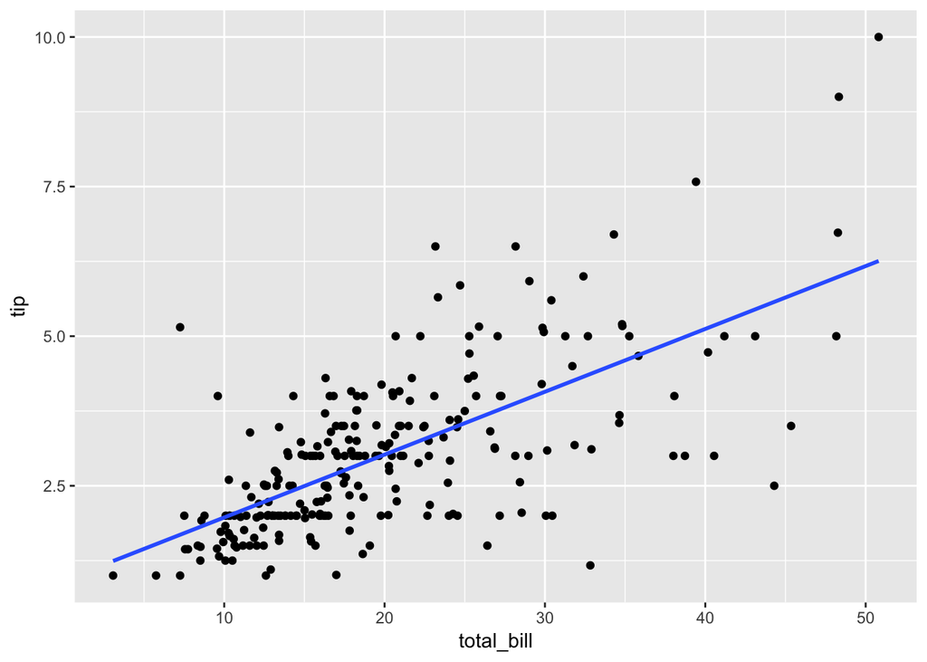

```r
ggplot(data=tips, aes(x= total_bill, y = tip))+ geom_point()+geom_smooth(method="lm", se= FALSE)
```

6. Introduce a variable tiprate into the data set, that incorporates the rate of tips. What is the average rate for tips?

```r
tips$tiprate<- (100)*(tips$tip/tips$total_bill)
summary(tips)
```

```
##    total_bill         tip             sex      smoker      day
##  Min.   : 3.07   Min.   : 1.000   Female: 87   No :151   Fri :19
##  1st Qu.:13.35   1st Qu.: 2.000   Male  :157   Yes: 93   Sat :87
##  Median :17.80   Median : 2.900                          Sun :76
##  Mean   :19.79   Mean   : 2.998                          Thur:62
##  3rd Qu.:24.13   3rd Qu.: 3.562
##  Max.   :50.81   Max.   :10.000
##      time          size         tiprate
##  Dinner:176   Min.   :1.00   Min.   : 3.564
##  Lunch : 68   1st Qu.:2.00   1st Qu.:12.913
##               Median :2.00   Median :15.477
##               Mean   :2.57   Mean   :16.080
##               3rd Qu.:3.00   3rd Qu.:19.148
##               Max.   :6.00   Max.   :71.034
```

The average tip rate is 16.1%.

7. Make a boxplot of the tip rate by time. The x-axis should be ordered by lunch and then dinner. Use the ggplot2 package to make a chart.

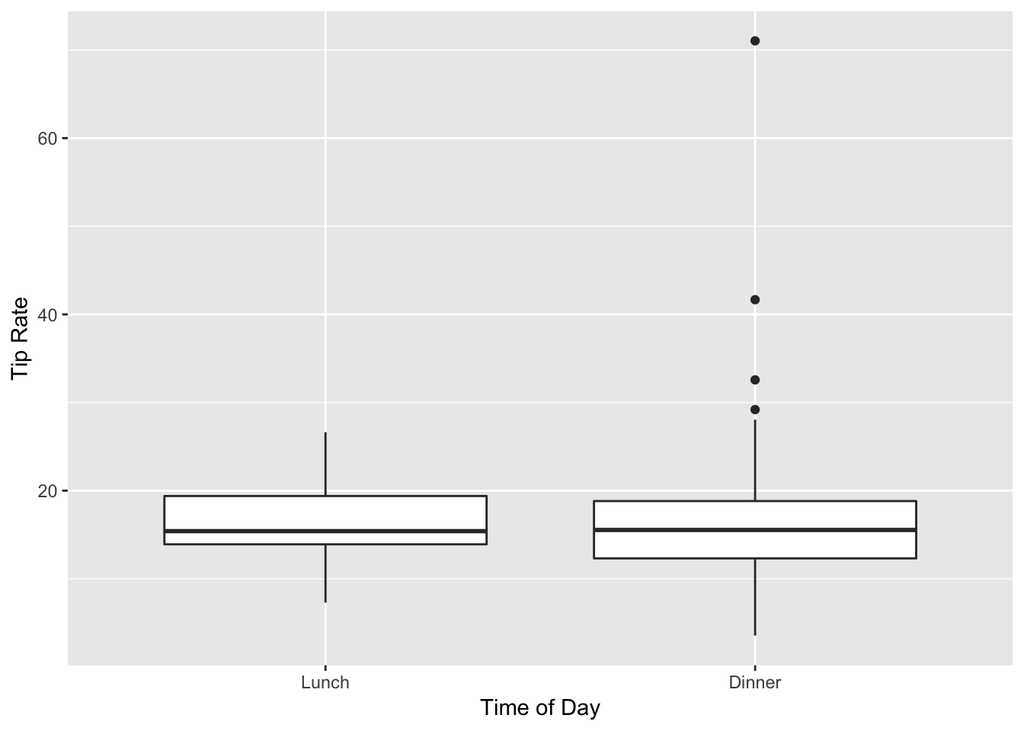

```r
ggplot(data=tips, aes(x=tips$time, y=tiprate))+geom_boxplot()+scale_x_discrete(limits=c("Lunch","Dinner"))+xlab("Time of Day")+ylab("Tip Rate")
```

8. How does smoking behavior and gender of the person who pays impact the relationship between tip and total bill? Find a visualization that incorporates all four variables. Interpret the result.

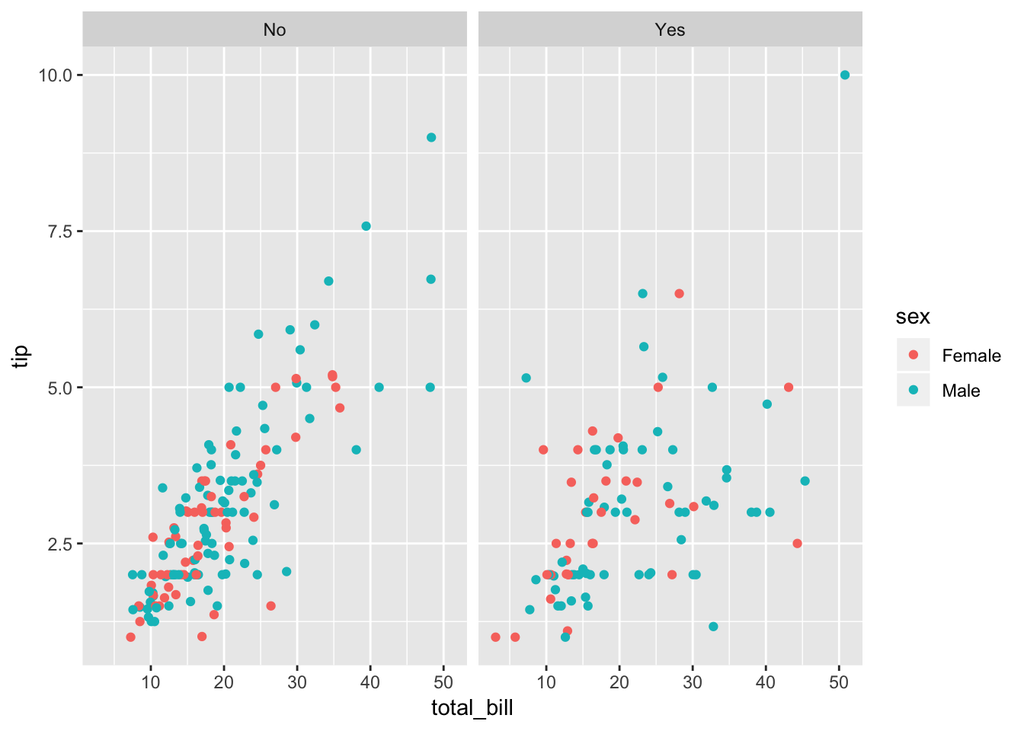

```r
ggplot(tips, aes(x=total_bill, y= tip, color=sex))+geom_point()+facet_wrap(~smoker)
```

Males tend to tip a little better than females, smokers tend to tip less than non smokers, there’s a more definite correlation between total and tip when it comes to non-smokers. Sex does not change much between smokers and non-smokers.

9. Use ggplot2 to find a graphical summary of the relationship between day of the week and gender of the person paying the bill. What can you say about this relationship?

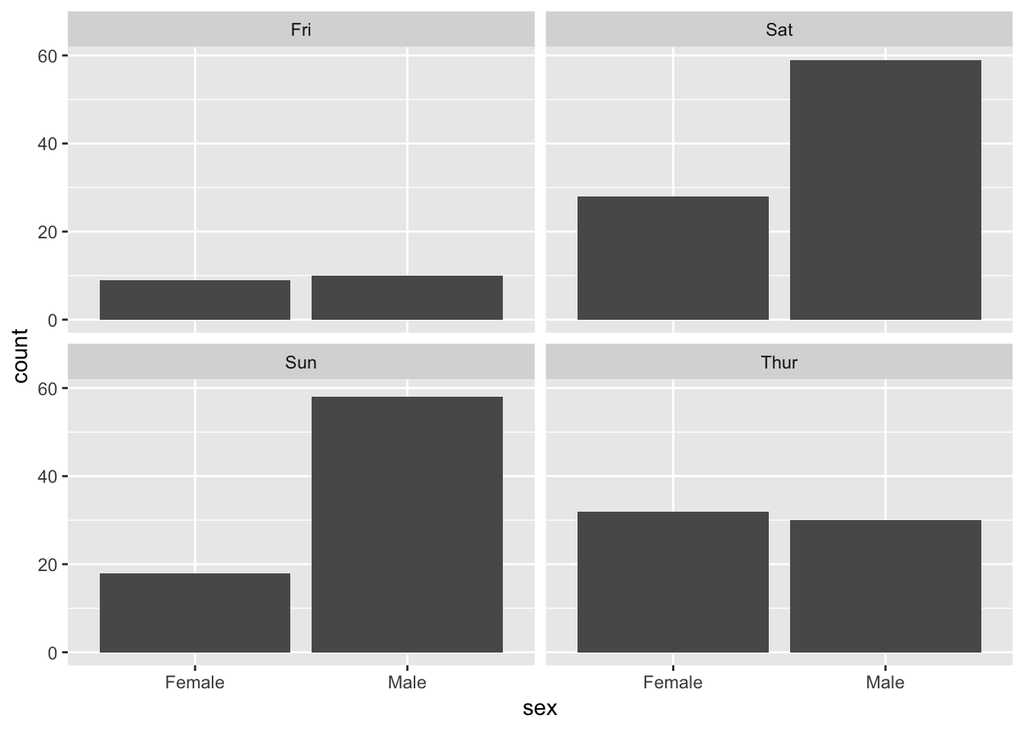

```r
ggplot(tips, aes(x=sex))+geom_bar()+facet_wrap(~day)
```

Typically on the weekend days (sat & sun) the males pay more, on Thursday and Friday females and males tend to pay equally.